# Intro to Ipython: Open source, interactive data science and scientific computing

## +Friends!

### Jupyter, Numpy, Pandas, SciPy, Scikit-Learn, NetworkX, & more...

# The Notebook: Jupyter

An interactive, cell-based computing environment for writing, developing, and presenting your code.

Stands for Ju(lia)+Pyt(hon)+R

- Everything here is easy to get using [Anaconda (2.7)](https://store.continuum.io/cshop/anaconda/)!

A lot of this presentation will be taken from the [Reveal Slideshow tour](http://www.damian.oquanta.info/posts/make-your-slides-with-ipython.html) (what I'm using now!)

```python
#This is the interface
print "hello world"
```

```
hello world
```

```python
#each cell defines anything you want, and can be run with SHIFT+ENTER
a=2
(b,c)=3,4
a+b-c
```

```
1
```

- CTRL+ENTER runs current cell,
- SHIFT+ENTER runs and moves on,
- ALT+ENTER inserts a new cell after running

**Two modes**: EDIT and COMMAND. Hit esc/enter to switch between.

```python
pwd
```

```
u'C:\\Users\\p2admin\\Documents\\F15_MAE301'
```

```python
ls
```

```
 Volume in drive C is Windows
 Volume Serial Number is 0AE0-C2BA

 Directory of C:\Users\p2admin\Documents\F15_MAE301

09/16/2015  09:40 AM    <DIR>          .
09/16/2015  09:40 AM    <DIR>          ..
09/16/2015  09:40 AM                22 .cvsignore
09/16/2015  09:40 AM    <DIR>          .idea
08/25/2015  03:03 PM    <DIR>          .ipynb_checkpoints
09/16/2015  09:40 AM            51,572 data.txt
09/16/2015  09:40 AM           434,566 IPython&Friends.ipynb
09/16/2015  09:41 AM           659,138 IPython&Friends.slides.html
09/16/2015  09:40 AM           184,666 MAE301HW1_Answers.ipynb
08/24/2015  11:20 AM           390,489 MAE301HW1_Student.html
08/25/2015  03:06 PM           180,545 MAE301HW1_Student.ipynb
09/16/2015  09:40 AM             6,155 MAE301HW2_Answer.ipynb
09/16/2015  09:40 AM             3,294 MAE301HW2_Student.ipynb
09/16/2015  09:40 AM             6,529 MAE301HW3_Student.ipynb
08/24/2015  11:20 AM                14 README.md
              11 File(s)      1,916,990 bytes
               4 Dir(s)  173,986,836,480 bytes free
```

```python
message = 'Access old variables in ANY cell...will use most recent definition!'

print message+"\nWe still have a =",a,",b =",b,", and c =",c,"."
```

```
Access old variables in ANY cell...will use most recent definition!
We still have a = 2 ,b = 3 , and c = 4 .
```

Plot INLINE with Matplotlib (or not!)

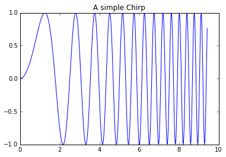

```python
%matplotlib inline
# ^ one of many "ipython magics"
import matplotlib.pyplot as plt
import numpy as np

x=np.linspace(0,3*np.pi,500)
plt.plot(x,np.sin(x**2))
plt.title("A simple Chirp")

# use "%matplotlib" alone to get interactive window plot,
# and "%matplotlib qt" to get out of inline mode
```

Errors are useful here:

```python
%run the_non_file
```

```
ERROR: File `u'the_non_file.py'` not found.
```

```python
z=b/(2-a)
```

```
---------------------------------------------------------------------------
ZeroDivisionError                         Traceback (most recent call last)
<ipython-input-16-57d62978c8fa> in <module>()
----> 1 z=b/(2-a)

ZeroDivisionError: integer division or modulo by zero
```

Also, Access inline docs for ANY imported or self-defined function using `SHIFT+TAB`

Most files in the `pwd` can be accessed automatically using TAB-completion, as well as any vars or functions.

## Rich Display system

- HTML
- JSON
- PNG
- JPEG
- SVG
- **LaTeX** (via MathJax rendering)
- Markdown (Github/Reddit Style)
- YouTube Embedding
- Entire HTML Sites
- Soundcloud
- more...

More latex please! Can be done via command window (messy):

```python
from IPython.display import Math
Math(r'F(k) = \int_{-\infty}^{\infty} f(x) e^{2\pi i k} dx')
```

$$F(k) = \int_{-\infty}^{\infty} f(x) e^{2\pi i k} dx$$

```python
from IPython.display import Latex
Latex(r"""\begin{eqnarray}
\nabla \times \vec{\mathbf{B}} -\, \frac1c\, \frac{\partial\vec{\mathbf{E}}}{\partial t} & = \frac{4\pi}{c}\vec{\mathbf{j}} \\
\nabla \cdot \vec{\mathbf{E}} & = 4 \pi \rho \\
\nabla \times \vec{\mathbf{E}}\, +\, \frac1c\, \frac{\partial\vec{\mathbf{B}}}{\partial t} & = \vec{\mathbf{0}} \\
\nabla \cdot \vec{\mathbf{B}} & = 0
\end{eqnarray}""")
```

\begin{eqnarray} \nabla \times \vec{\mathbf{B}} -\, \frac1c\, \frac{\partial\vec{\mathbf{E}}}{\partial t} & = \frac{4\pi}{c}\vec{\mathbf{j}} \\ \nabla \cdot \vec{\mathbf{E}} & = 4 \pi \rho \\ \nabla \times \vec{\mathbf{E}}\, +\, \frac1c\, \frac{\partial\vec{\mathbf{B}}}{\partial t} & = \vec{\mathbf{0}} \\ \nabla \cdot \vec{\mathbf{B}} & = 0 \end{eqnarray}

Or INSIDE of the Markdown, so that the same $F(k)$, `$$F(k) = \int_{-\infty}^{\infty} f(x) e^{2\pi i k} dx$$` looks like $$F(k) = \int_{-\infty}^{\infty} f(x) e^{2\pi i k} dx$$ Right inline with your text, and with no nasty code.

### I **strongly encourage** you to google LaTeX and Markdown basic tutorials. Fantastic to know!

Slight caveat...Tables are not so easy to do (without a dataframe from pandas):

- Markdown style (eesh)

  ```
  | $x$          | 4       | 5       | 6       | 7     |
  |--------    |-----    |-----    |-----    |---    |
  | $P(X=x)$     | 0.2     | 0.4     | 0.3     | 0.1    |
  ```

| $x$ | 4 | 5 | 6 | 7 |
| --- | --- | --- | --- | --- |
| $P(X=x)$ | 0.2 | 0.4 | 0.3 | 0.1 |

- MathJax array:

```
\begin{array} {|r|r|}
\hline
    x &4 &5 &6 &7 \\
\hline
    P(X=x) &0.2 &0.4 &0.3 &0.1 \\
\hline
\end{array}
```

\begin{array} {|r|r|} \hline x &4 &5 &6 &7 \\ \hline P(X=x) &0.2 &0.4 &0.3 &0.1 \\ \hline \end{array}

## Load your scripts:

- Drag and drop a .py in the dashboard
- Use `%load` with any local or remote url: the Matplotlib Gallery! (auto-comments the load command!)
- Use `%run` to directly define all vars and functions in a .py file in the directory, w/o seeing the code.

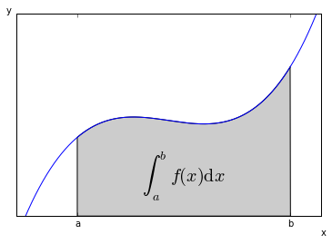

```python
# %load http://matplotlib.sourceforge.net/mpl_examples/pylab_examples/integral_demo.py
#!/usr/bin/env python

# implement the example graphs/integral from pyx
from pylab import *
from matplotlib.patches import Polygon

def func(x):
    return (x-3)*(x-5)*(x-7)+85

ax = subplot(111)

a, b = 2, 9 # integral area
x = arange(0, 10, 0.01)
y = func(x)
plot(x, y, linewidth=1)

# make the shaded region
ix = arange(a, b, 0.01)
iy = func(ix)
verts = [(a,0)] + list(zip(ix,iy)) + [(b,0)]
poly = Polygon(verts, facecolor='0.8', edgecolor='k')
ax.add_patch(poly)

text(0.5 * (a + b), 30,
     r"$\int_a^b f(x)\mathrm{d}x$", horizontalalignment='center',
     fontsize=20)

axis([0,10, 0, 180])
figtext(0.9, 0.05, 'x')
figtext(0.1, 0.9, 'y')
ax.set_xticks((a,b))
ax.set_xticklabels(('a','b'))
ax.set_yticks([])
show()
```

# Dealing with Data: Numpy, Pandas, and Seaborn

When you need plots, and you need them now

Check out [this guy's post](http://twiecki.github.io/blog/2014/11/18/python-for-data-science/) for some of the info sources I'll be going through.

### Pandas: The R-alternative (replacement?) for Python

Numpy is basically a fantastic MatLab replacement, with loads of Object oriented goodness baked in. It really is the basis for most other Scientific computing modules now-a-days. Worth an entire talk, but it's *basically* MatLab style.

Pandas is a **fantastic** library (again, based on Numpy) for creating, analyzing, plotting, and reading in data:

```python
import pandas as pd

df = pd.DataFrame({ 'A' : 1.,
                    'B' : pd.Timestamp('20130102'),
                    'C' : pd.Series(1, index=list(range(4)), dtype='float32'),
                    'D' : pd.Series([1, 2, 1, 2], dtype='int32'),
                    'E' : pd.Categorical(["test", "train", "test", "train"]),
                    'F' : 'foo' })
```

```python
df
```

|  | A | B | C | D | E | F |
| --- | --- | --- | --- | --- | --- | --- |
| 0 | 1 | 2013-01-02 | 1 | 1 | test | foo |
| 1 | 1 | 2013-01-02 | 1 | 2 | train | foo |
| 2 | 1 | 2013-01-02 | 1 | 1 | test | foo |
| 3 | 1 | 2013-01-02 | 1 | 2 | train | foo |

```python
#columns accesed by NAME!
df.B
```

```
0   2013-01-02
1   2013-01-02
2   2013-01-02
3   2013-01-02
Name: B, dtype: datetime64[ns]
```

```python
# Compute the sum of D for each category in E:
df.groupby('E').sum().D
```

```
E
test     2
train    4
Name: D, dtype: int32
```

There is SO much more. It's a very mature statistics and Data analysis tool at this stage.

Go to [10min to Pandas](http://pandas.pydata.org/pandas-docs/stable/10min.html) for much more.

### Seaborn-ify it:

Similarly to Numpy, Matplotlib is like the grandaddy of Python Plotting. There are some beautiful modules to improve it.

- Beautify standard plots:

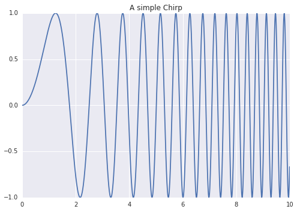

```python
import seaborn as sns
plt.plot(x,np.sin(x**2))
plt.title("A simple Chirp")
```

- Use fantastic built-in plotting functions

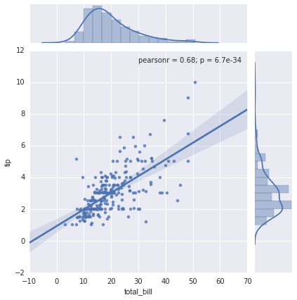

```python
# Load one of the data sets that come with seaborn
tips = sns.load_dataset("tips")

sns.jointplot("total_bill", "tip", tips, kind='reg');
```

- Plays **really** nice with Pandas:

```python
# guess what the data set was?
tips.head()
```

|  | total_bill | tip | sex | smoker | day | time | size |
| --- | --- | --- | --- | --- | --- | --- | --- |
| 0 | 16.99 | 1.01 | Female | No | Sun | Dinner | 2 |
| 1 | 10.34 | 1.66 | Male | No | Sun | Dinner | 3 |
| 2 | 21.01 | 3.50 | Male | No | Sun | Dinner | 3 |
| 3 | 23.68 | 3.31 | Male | No | Sun | Dinner | 2 |
| 4 | 24.59 | 3.61 | Female | No | Sun | Dinner | 4 |

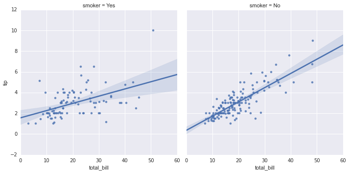

```python
sns.lmplot("total_bill", "tip", tips, col="smoker");
```

# Advanced Topics: Scikit-Learn, Sympy, and NetworkX

It's just the tip of the iceberg. Seriously.

### Scikit-Learn: Machine Learning (yeah, all of it)

This thing is [HUGE](http://scikit-learn.org/stable/). This [ipython cookbook page](http://ipython-books.github.io/featured-04/) is huge, and hardly covers any of it.

**Spotify, Evernote, OkCupid**, and more use this thing for classification, regression, and other awesome stuff.

I used this in undergrad for Feature-Selection in Regression modeling. [Optimal Modeling of Knots in Wood](http://archaeo.engineer/portfolio-item/honors-thesis-optimal-modeling-of-knots-in-wood/)

- There's WAY too much to cover, so go forth and discover.
- Note! NOT for Neural net. Check out PyBrain and others for that.
- First, check this stuff out...it's pretty sweet.

```
Estimated coefficients (true, normal, RANSAC):
(array(82.1903908407869), array([ 54.17236387]), array([[ 82.08533159]]))
```

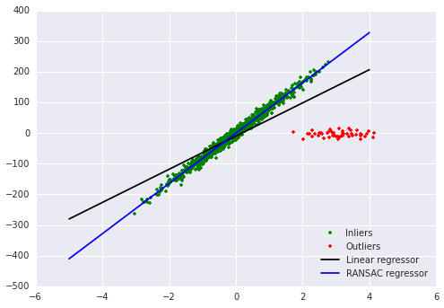

```python
# Robust Regression with Outlier detection
from sklearn import linear_model, datasets


n_samples = 1000
n_outliers = 50


X, y, coef = datasets.make_regression(n_samples=n_samples, n_features=1,
                                      n_informative=1, noise=10,
                                      coef=True, random_state=0)

# Add outlier data
np.random.seed(0)
X[:n_outliers] = 3 + 0.5 * np.random.normal(size=(n_outliers, 1))
y[:n_outliers] = -3 + 10 * np.random.normal(size=n_outliers)

# Fit line using all data
model = linear_model.LinearRegression()
model.fit(X, y)

# Robustly fit linear model with RANSAC algorithm
model_ransac = linear_model.RANSACRegressor(linear_model.LinearRegression())
model_ransac.fit(X, y)
inlier_mask = model_ransac.inlier_mask_
outlier_mask = np.logical_not(inlier_mask)

# Predict data of estimated models
line_X = np.arange(-5, 5)
line_y = model.predict(line_X[:, np.newaxis])
line_y_ransac = model_ransac.predict(line_X[:, np.newaxis])

# Compare estimated coefficients
print("Estimated coefficients (true, normal, RANSAC):")
print(coef, model.coef_, model_ransac.estimator_.coef_)

plt.plot(X[inlier_mask], y[inlier_mask], '.g', label='Inliers')
plt.plot(X[outlier_mask], y[outlier_mask], '.r', label='Outliers')
plt.plot(line_X, line_y, '-k', label='Linear regressor')
plt.plot(line_X, line_y_ransac, '-b', label='RANSAC regressor')
plt.legend(loc='lower right')
```

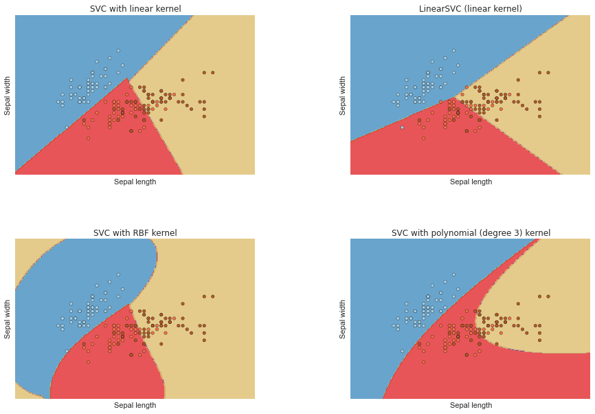

```python
#Support Vector Machine, for Classification
from sklearn import svm, datasets

# import some data to play with
iris = datasets.load_iris()
X = iris.data[:, :2]  # we only take the first two features. We could
                      # avoid this ugly slicing by using a two-dim dataset
y = iris.target

h = .02  # step size in the mesh

# we create an instance of SVM and fit out data. We do not scale our
# data since we want to plot the support vectors
C = 1.0  # SVM regularization parameter
svc = svm.SVC(kernel='linear', C=C).fit(X, y)
rbf_svc = svm.SVC(kernel='rbf', gamma=0.7, C=C).fit(X, y)
poly_svc = svm.SVC(kernel='poly', degree=3, C=C).fit(X, y)
lin_svc = svm.LinearSVC(C=C).fit(X, y)

# create a mesh to plot in
x_min, x_max = X[:, 0].min() - 1, X[:, 0].max() + 1
y_min, y_max = X[:, 1].min() - 1, X[:, 1].max() + 1
xx, yy = np.meshgrid(np.arange(x_min, x_max, h),
                     np.arange(y_min, y_max, h))

# title for the plots
titles = ['SVC with linear kernel',
          'LinearSVC (linear kernel)',
          'SVC with RBF kernel',
          'SVC with polynomial (degree 3) kernel']

plt.figure(figsize=(15,10))
for i, clf in enumerate((svc, lin_svc, rbf_svc, poly_svc)):
    # Plot the decision boundary. For that, we will assign a color to each
    # point in the mesh [x_min, m_max]x[y_min, y_max].
    plt.subplot(2, 2, i + 1)
    plt.subplots_adjust(wspace=0.4, hspace=0.4)

    Z = clf.predict(np.c_[xx.ravel(), yy.ravel()])

    # Put the result into a color plot
    Z = Z.reshape(xx.shape)
    plt.contourf(xx, yy, Z, cmap=plt.cm.Paired, alpha=0.8)

    # Plot also the training points
    plt.scatter(X[:, 0], X[:, 1], c=y, cmap=plt.cm.Paired)
    plt.xlabel('Sepal length')
    plt.ylabel('Sepal width')
    plt.xlim(xx.min(), xx.max())
    plt.ylim(yy.min(), yy.max())
    plt.xticks(())
    plt.yticks(())
    plt.title(titles[i])
```

### Sympy: Computer Algebra System for Python

This is a sort of swiss-army knife for math. If you find yourself switching back and forth from wolfram alpha to show steps of algebra, maybe try this out!

- Calculus
- Diff-Eq
- Linear ALgebra
- Plotting
- LaTeX Pretty Printing!

```python
from sympy import Integral, Symbol, pprint
from sympy import init_printing
init_printing()

x = Symbol("x")
y = Symbol("y")

e = 1/(x + y)
s = e.series(x, 0, 5) #auto Taylor series!

print(s)
s
```

```
1/y - x/y**2 + x**2/y**3 - x**3/y**4 + x**4/y**5 + O(x**5)
```

$$\frac{1}{y} - \frac{x}{y^{2}} + \frac{x^{2}}{y^{3}} - \frac{x^{3}}{y^{4}} + \frac{x^{4}}{y^{5}} + \mathcal{O}\left(x^{5}\right)$$

```python
from sympy import symbols, Function, dsolve
f = symbols("f", cls=Function)
f(x).diff(x, x) + f(x)
```

$$f{\left (x \right )} + \frac{d^{2}}{d x^{2}} f{\left (x \right )}$$

```python
dsolve(f(x).diff(x, x) + f(x), f(x))
```

$$f{\left (x \right )} = C_{1} \sin{\left (x \right )} + C_{2} \cos{\left (x \right )}$$

```python
# I Hate Partial Frac Decomp.
from sympy.polys.partfrac import apart
f = apart(5/(x + 2)/(x + 1), x)
f
```

$$- \frac{5}{x + 2} + \frac{5}{x + 1}$$

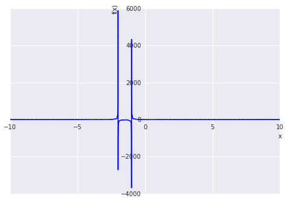

```
<sympy.plotting.plot.Plot at 0xb3b5b38>
```

```python
from sympy.plotting import plot
plot(f)
```

### NetworkX: Graph Theory and Network Analysis

One of my personal favorites. You never know when it may be convenient to express something as a graph. NetworkX Builds these with Dictionaries of edges and Nodes

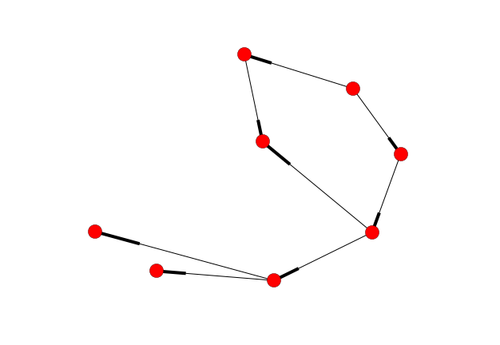

```python
import networkx as nx
#from nxpd import draw
G = nx.DiGraph()
G.graph['dpi'] = 700
G.add_nodes_from(range(1,9))
G.add_edges_from([(1,2),(1,3),(2,4),(3,6),(4,5),(4,6),(5,7),(5,8)])
nx.draw_spring(G)
```

```python
print G.adj
nx.adjacency_matrix(G).todense()
```

```
{1: {2: {}, 3: {}}, 2: {4: {}}, 3: {6: {}}, 4: {5: {}, 6: {}}, 5: {8: {}, 7: {}}, 6: {}, 7: {}, 8: {}}
```

```
matrix([[0, 1, 1, 0, 0, 0, 0, 0],
        [0, 0, 0, 1, 0, 0, 0, 0],
        [0, 0, 0, 0, 0, 1, 0, 0],
        [0, 0, 0, 0, 1, 1, 0, 0],
        [0, 0, 0, 0, 0, 0, 1, 1],
        [0, 0, 0, 0, 0, 0, 0, 0],
        [0, 0, 0, 0, 0, 0, 0, 0],
        [0, 0, 0, 0, 0, 0, 0, 0]])
```

- Many pre-built graph generators and analysis functions:

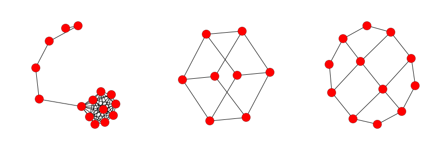

```python
fig,ax=plt.subplots(nrows=1, ncols=3, figsize=(15,5))
nx.draw_spring(nx.lollipop_graph(10,5), ax=ax[0])
nx.draw_spring(nx.hypercube_graph(3), ax=ax[1])
nx.draw_spring(nx.grid_graph(dim=[3,4]), ax=ax[2])
```

```python
print "Clustering:\nLollipop: \t",nx.average_clustering(nx.lollipop_graph(10,5))
print "HyperCube: \t", nx.average_clustering(nx.hypercube_graph(3))
print "Grid Graph: \t", nx.average_clustering(nx.grid_graph(dim=[3,4]))
```

```
Clustering:
Lollipop: 	0.653333333333
HyperCube: 	0.0
Grid Graph: 	0.0
```

Undergrad: used for quite a bit:

- Dynamic Simulation of Small-world graphs under various "insurance" schemes based on connectivity and wealth
- Optimizing over a Smart Grid energy transfer network, to build Phoenix an "optimal" Grid (A* is built into NX!)